# Study 5

Analyses

28 January, 2022

# Notes

Both MHS and MASS have been scored for this study so that higher scores are desirable, i.e., represent lower homophobia. This is so that (a) there is a congruent interpretation of directionality in the analyses, and (b) so that positive Cohen’s d scores in the meta analyses represent improvement, which is typical.

Error bars are 95% Confidence Intervals calculated as 1.96 +/- SE, where Standard Errors are calculated from the data directly (i.e., the empirical SEs by condition, not the model-implied SEs in the case of repeated-measures plots), where SE = SD/sqrt(N). Inferences are not made on the basis of these plots (e.g., based on the CIs) but on the basis of the ANOVAs and any required contrast tests (with familywise corrections). In addition to this, there are not models fitted to the raw data, only the between time-point difference scores. As such, there are no model-implied SEs to calculate CIs from.

# Dependencies

```r
library(tidyverse)
library(ez)
library(schoRsch)
library(knitr)
library(kableExtra)
library(psych)
library(plotrix)

# make directory
dir.create("plots")

# plotting function
plot_descriptives <- function(data_raw, data_summary){
  ggplot(data = data_summary) +
    geom_point(data = data_raw,
               aes(x = timepoint,
                   y = score,
                   shape = condition,
                   color = condition,
                   group = condition),
               position = position_jitterdodge(dodge.width = 0.3,
                                               jitter.width = 0.1),
               size = 1,
               alpha = 0.35) +
    geom_line(data = data_summary,
              aes(x = timepoint,
                  y = mean,
                  color = condition,
                  group = condition),
              position = position_dodge(width = 0.3)) +
    geom_errorbar(data = data_summary,
                  aes(x = timepoint,
                      y = mean,
                      ymin = mean - se*1.96,
                      ymax = mean + se*1.96,
                      color = condition,
                      group = condition),
                  width = 0.2,
                  position = position_dodge(width = 0.3)) +
    geom_point(data = data_summary,
               aes(x = timepoint,
                   y = mean,
                   shape = condition,
                   color = condition,
                   group = condition),
               position = position_dodge(width = 0.3),
               size = 2) +
    theme_linedraw() +
    scale_color_viridis_d(begin = 0.3, end = 0.7,
                          name = "Level of participant burden",
                          labels = c("No PT", "Traditional PT", "Modelled PT")) +
    scale_shape_manual(name = "Level of participant burden",
                       labels = c("No PT", "Traditional PT", "Modelled PT"),
                       values = c(16, 15, 17)) +
    xlab("Timepoint")
}


plot_condition_main_effect <- function(data) {
  ggplot(data,
         aes(x = condition,
             y = mean)) +
    geom_hline(yintercept = 0, linetype = "dashed") +
    # geom_line(position = position_dodge(width = 0.3)) +
    geom_errorbar(aes(ymin = mean - se*1.96, ymax = mean + se*1.96),
                  width = 0.2) +
    geom_point(size = 2) +
    theme_linedraw() +
    # theme_classic() +
    xlab("Intervention type")
}
```

# Get data

- NB MASS, MHS-G and MHS-L are all scored so that higher scores represent less homophobia, i.e., so that an increase in scores from pre to post/followup represents improvement.

```r
data_processed <- read_csv("../data/processed/data_processed.csv")

data_processed_after_exclusions <- data_processed %>%
  filter(exclude == FALSE) %>%
  mutate(id = as.factor(id),
         condition = case_when(condition == "Video, watch" ~ "No PT",
                               condition == "Video, traditional PT" ~ "Traditional PT",
                               condition == "Video, modelled PT" ~ "Modelled PT"),
         condition = fct_relevel(as.factor(condition), "No PT", "Traditional PT", "Modelled PT"),
         attrition_at_followup = fct_relevel(as.factor(attrition_at_followup), "TRUE", "FALSE"))
```

# Sample

## Sample sizes

### Exclusions

Greater than 10% missing data on the baseline MHS/MASS scales or failed attention checks

```r
data_processed %>%
  count(exclude, missing = exclude_participant_based_on_missingness,
        attention = exclude_participant_attention_checks,
        sexuality = exclude_participant_non_heterosexual)
```

```
## # A tibble: 6 x 5
##   exclude missing attention sexuality     n
##   <lgl>   <lgl>   <lgl>     <lgl>     <int>
## 1 FALSE   FALSE   FALSE     FALSE       139
## 2 TRUE    FALSE   FALSE     TRUE          3
## 3 TRUE    TRUE    FALSE     FALSE        64
## 4 TRUE    TRUE    FALSE     TRUE          2
## 5 TRUE    TRUE    TRUE      FALSE        22
## 6 TRUE    TRUE    TRUE      NA            5
```

```r
data_processed %>%
  count(exclude) %>%
  arrange(desc(n)) %>%
  kable()  %>%
  kable_styling(bootstrap_options = c("striped", "hover", "condensed"), full_width = FALSE)
```

| exclude | n |
| --- | --- |
| FALSE | 139 |
| TRUE | 96 |

### Pre-post after exclusions

```r
data_processed_after_exclusions %>%
  count() %>%
  arrange() %>%
  kable()  %>%
  kable_styling(bootstrap_options = c("striped", "hover", "condensed"), full_width = FALSE)
```

| n |
| --- |
| 139 |

### Pre-followup after exclusions

```r
data_processed_after_exclusions %>%
  filter(attrition_at_followup == FALSE) %>%
  count() %>%
  arrange() %>%
  kable()  %>%
  kable_styling(bootstrap_options = c("striped", "hover", "condensed"), full_width = FALSE)
```

| n |
| --- |
| 110 |

## Demographics

After exclusions.

Sexuality not reported as non-heterosexuality was an exclusion criterion.

```r
data_processed_after_exclusions %>%
  summarize(mean_age = mean(age, na.rm = TRUE),
            sd_age = sd(age, na.rm = TRUE)) %>%
  mutate_if(is.numeric, round, digits = 2) %>%
  kable()  %>%
  kable_styling(bootstrap_options = c("striped", "hover", "condensed"), full_width = FALSE)
```

| mean_age | sd_age |
| --- | --- |
| 35.04 | 12.7 |

```r
data_processed_after_exclusions %>%
  count(gender) %>%
  kable()  %>%
  kable_styling(bootstrap_options = c("striped", "hover", "condensed"), full_width = FALSE)
```

| gender | n |
| --- | --- |
| Female | 71 |
| Male | 67 |
| You’re asking my gender but giving me biological sexes as the answer options. Sex and gender are not the same thing. My sex is female, I do not believe in gender stereotypes. | 1 |

```r
data_processed_after_exclusions %>%
  count(ethnicity) %>%
  arrange(desc(n)) %>%
  kable()  %>%
  kable_styling(bootstrap_options = c("striped", "hover", "condensed"), full_width = FALSE)
```

| ethnicity | n |
| --- | --- |
| White – English, Welsh, Scottish, Northern Irish, Irish, American, Canadian, Australian, other White background | 102 |
| Asian/Asian British – Indian/Pakistani/Bangladeshi/Chinese/other Asian background | 14 |
| Black/African/Caribbean/Black British | 14 |
| Mixed – White and Asian/Indian/Pakistani/Bangladeshi/Chinese/other Asian background | 3 |
| Mixed – Asian and Black Caribbean/Black African/Black British | 2 |
| Mixed – White and Black Caribbean/Black African, Black British | 2 |
| Mixed - White/Native American | 1 |
| Prefer not to say | 1 |

# Internal consistency

## MASS

### Version A

```r
results_alpha_mass_a <- data_processed_after_exclusions %>%
  filter(task_order == "MASS & SD form A first") %>%
  select(starts_with("mass_pre_"), -mass_pre_sum_score) %>%
  alpha(., check.keys = FALSE)

results_alpha_mass_a$total["raw_alpha"] %>%
  mutate_all(round, digits = 2) %>%
  kable() %>%
  kable_styling(bootstrap_options = c("striped", "hover", "condensed"), full_width = FALSE)
```

|  | raw_alpha |
| --- | --- |
|  | 0.86 |

### Version B

```r
results_alpha_mass_b <- data_processed_after_exclusions %>%
  filter(task_order == "MASS & SD form B first") %>%
  select(starts_with("mass_pre_"), -mass_pre_sum_score) %>%
  alpha(., check.keys = FALSE)

results_alpha_mass_b$total["raw_alpha"] %>%
  mutate_all(round, digits = 2) %>%
  kable() %>%
  kable_styling(bootstrap_options = c("striped", "hover", "condensed"), full_width = FALSE)
```

|  | raw_alpha |
| --- | --- |
|  | 0.94 |

## MHS-G

```r
results_alpha_mhs_g <- data_processed_after_exclusions %>%
  select(mhs_g_pre_1,
         mhs_g_pre_2,
         mhs_g_pre_3,
         mhs_g_pre_4,
         mhs_g_pre_5,
         mhs_g_pre_6,
         mhs_g_pre_7,
         mhs_g_pre_8,
         mhs_g_pre_9,
         mhs_g_pre_10,
         mhs_g_pre_11,
         mhs_g_pre_12) %>%
  alpha(., check.keys = FALSE)

results_alpha_mhs_g$total["raw_alpha"] %>%
  mutate_all(round, digits = 2) %>%
  kable() %>%
  kable_styling(bootstrap_options = c("striped", "hover", "condensed"), full_width = FALSE)
```

|  | raw_alpha |
| --- | --- |
|  | 0.87 |

## MHS-L

```r
results_alpha_mhs_l <- data_processed_after_exclusions %>%
  select(mhs_l_pre_1,
         mhs_l_pre_2,
         mhs_l_pre_3,
         mhs_l_pre_4,
         mhs_l_pre_5,
         mhs_l_pre_6,
         mhs_l_pre_7,
         mhs_l_pre_8,
         mhs_l_pre_9,
         mhs_l_pre_10,
         mhs_l_pre_11,
         mhs_l_pre_12) %>%
  alpha(., check.keys = FALSE)

results_alpha_mhs_l$total["raw_alpha"] %>%
  mutate_all(round, digits = 2) %>%
  kable() %>%
  kable_styling(bootstrap_options = c("striped", "hover", "condensed"), full_width = FALSE)
```

|  | raw_alpha |
| --- | --- |
|  | 0.88 |

## SD

### Version A

```r
results_alpha_sd_a <- data_processed_after_exclusions %>%
  filter(task_order == "MASS & SD form A first") %>%
  select(starts_with("sd_pre_"), -sd_pre_sum_score) %>%
  alpha(., check.keys = FALSE)

results_alpha_sd_a$total["raw_alpha"] %>%
  mutate_all(round, digits = 2) %>%
  kable() %>%
  kable_styling(bootstrap_options = c("striped", "hover", "condensed"), full_width = FALSE)
```

|  | raw_alpha |
| --- | --- |
|  | 0.74 |

### Version B

```r
results_alpha_sd_b <- data_processed_after_exclusions %>%
  filter(task_order == "MASS & SD form B first") %>%
  select(starts_with("sd_pre_"), -sd_pre_sum_score) %>%
  alpha(., check.keys = FALSE)

results_alpha_sd_b$total["raw_alpha"] %>%
  mutate_all(round, digits = 2) %>%
  kable() %>%
  kable_styling(bootstrap_options = c("striped", "hover", "condensed"), full_width = FALSE)
```

|  | raw_alpha |
| --- | --- |
|  | 0.79 |

## TOE

```r
results_alpha_toe <- data_processed_after_exclusions %>%
  select(starts_with("toe_"), -toe_sum_score) %>%
  alpha(., check.keys = FALSE)

results_alpha_toe$total["raw_alpha"] %>%
  mutate_all(round, digits = 2) %>%
  kable() %>%
  kable_styling(bootstrap_options = c("striped", "hover", "condensed"), full_width = FALSE)
```

|  | raw_alpha |
| --- | --- |
|  | 0.9 |

## IRI

NB This throws a suggestion that some items be reverse scored. They have been double checked and are correct.

```r
results_alpha_iri <- data_processed_after_exclusions %>%
  select(starts_with("iri_"), -iri_sum_score) %>%
  alpha(., check.keys = FALSE)
```

```
## Some items ( iri_19 iri_24 ) were negatively correlated with the total scale and
## probably should be reversed.
## To do this, run the function again with the 'check.keys=TRUE' option
```

```r
results_alpha_iri$total["raw_alpha"] %>%
  mutate_all(round, digits = 2) %>%
  kable() %>%
  kable_styling(bootstrap_options = c("striped", "hover", "condensed"), full_width = FALSE)
```

|  | raw_alpha |
| --- | --- |
|  | 0.88 |

# Descriptive plots

## MASS

```r
data_temp_mass <- data_processed_after_exclusions %>%
  select(Pre = mass_pre_sum_score,
         Post = mass_post_sum_score,
         Followup = mass_followup_sum_score,
         condition) %>%
  drop_na() %>%
  pivot_longer(names_to = "timepoint",
               values_to = "score",
               cols = c("Pre", "Post", "Followup")) %>%
  mutate(timepoint = fct_relevel(timepoint, "Pre", "Post", "Followup"))

data_temp_summary_mass <- data_temp_mass %>%
  group_by(condition, timepoint) %>%
  summarize(mean = mean(score),
            se = plotrix::std.error(score),
            sd = sd(score))

data_temp_summary_mass %>%
  mutate_if(is.numeric, round, digits = 2) %>%
  select(-se) %>%
  rename(Condition = condition,
         Timepoint = timepoint,
         M = mean,
         SD = sd) %>%
  kable() %>%
  kable_styling(bootstrap_options = c("striped", "hover", "condensed"), full_width = FALSE)
```

| Condition | Timepoint | M | SD |
| --- | --- | --- | --- |
| No PT | Pre | 68.29 | 10.70 |
| No PT | Post | 71.00 | 13.76 |
| No PT | Followup | 69.66 | 12.90 |
| Traditional PT | Pre | 66.86 | 14.18 |
| Traditional PT | Post | 72.01 | 8.05 |
| Traditional PT | Followup | 65.41 | 13.57 |
| Modelled PT | Pre | 69.71 | 11.48 |
| Modelled PT | Post | 72.87 | 11.10 |
| Modelled PT | Followup | 69.97 | 11.32 |

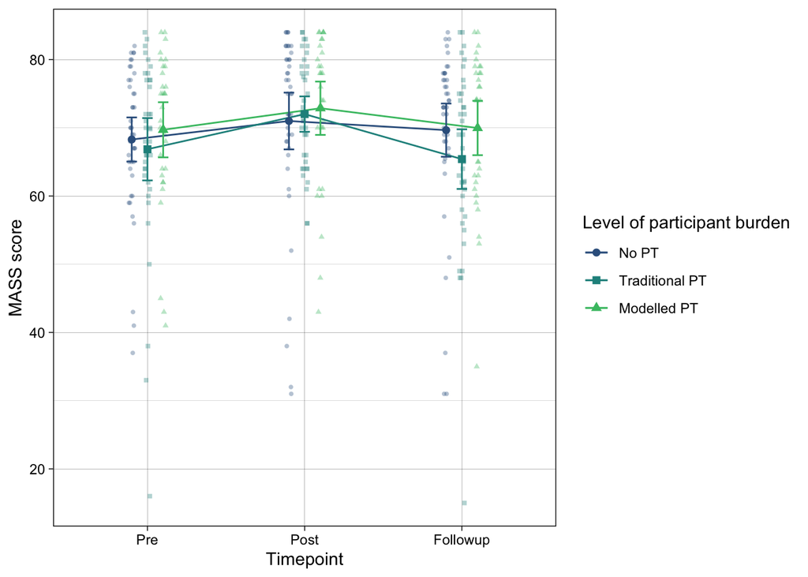

```r
plot_descriptive_mass <-
  plot_descriptives(data_raw = data_temp_mass, data_summary = data_temp_summary_mass) +
  ylab("MASS score")

# print
plot_descriptive_mass
```

```r
# save pdf
ggsave(plot = plot_descriptive_mass,
       device = "pdf",
       filename = "plot_descriptive_mass.pdf",
       path = "plots/",
       units = "in",
       width = 9,
       height = 6)
```

## MHS-G

```r
data_temp_mhs_g <- data_processed_after_exclusions %>%
  select(Pre = mhs_g_pre_sum_score,
         Post = mhs_g_post_sum_score,
         Followup = mhs_g_followup_sum_score,
         condition) %>%
  drop_na() %>%
  pivot_longer(names_to = "timepoint",
               values_to = "score",
               cols = c("Pre", "Post", "Followup")) %>%
  mutate(timepoint = fct_relevel(timepoint, "Pre", "Post", "Followup"))

data_temp_summary_mhs_g <- data_temp_mhs_g %>%
  group_by(condition, timepoint) %>%
  summarize(mean = mean(score),
            se = plotrix::std.error(score),
            sd = sd(score))

data_temp_summary_mhs_g %>%
  mutate_if(is.numeric, round, digits = 2) %>%
  select(-se) %>%
  rename(Condition = condition,
         Timepoint = timepoint,
         M = mean,
         SD = sd) %>%
  kable() %>%
  kable_styling(bootstrap_options = c("striped", "hover", "condensed"), full_width = FALSE)
```

| Condition | Timepoint | M | SD |
| --- | --- | --- | --- |
| No PT | Pre | 53.78 | 11.21 |
| No PT | Post | 58.71 | 11.28 |
| No PT | Followup | 57.03 | 13.09 |
| Traditional PT | Pre | 51.68 | 11.41 |
| Traditional PT | Post | 55.54 | 13.60 |
| Traditional PT | Followup | 56.18 | 13.50 |
| Modelled PT | Pre | 52.90 | 10.53 |
| Modelled PT | Post | 55.67 | 9.97 |
| Modelled PT | Followup | 55.00 | 12.98 |

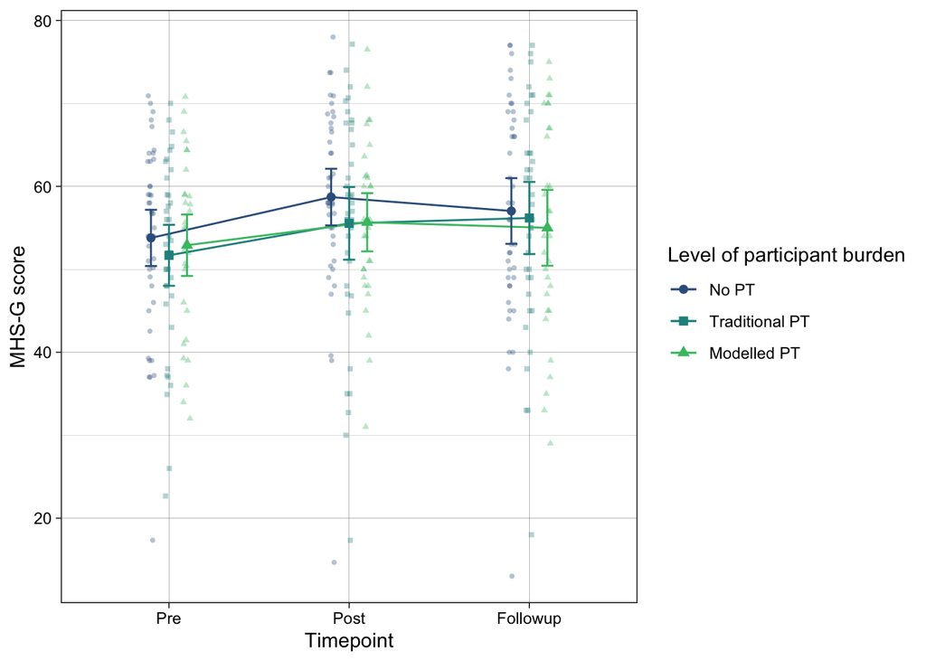

```r
plot_descriptive_mhs_g <-
  plot_descriptives(data_raw = data_temp_mhs_g, data_summary = data_temp_summary_mhs_g) +
  ylab("MHS-G score")

# print
plot_descriptive_mhs_g
```

```r
# save pdf
ggsave(plot = plot_descriptive_mhs_g,
       device = "pdf",
       filename = "plot_descriptive_mhs_g.pdf",
       path = "plots/",
       units = "in",
       width = 9,
       height = 6)
```

## MHS-L

```r
data_temp_mhs_l <- data_processed_after_exclusions %>%
  select(Pre = mhs_l_pre_sum_score,
         Post = mhs_l_post_sum_score,
         Followup = mhs_l_followup_sum_score,
         condition) %>%
  drop_na() %>%
  pivot_longer(names_to = "timepoint",
               values_to = "score",
               cols = c("Pre", "Post", "Followup")) %>%
  mutate(timepoint = fct_relevel(timepoint, "Pre", "Post", "Followup"))

data_temp_summary_mhs_l <- data_temp_mhs_l %>%
  group_by(condition, timepoint) %>%
  summarize(mean = mean(score),
            se = plotrix::std.error(score),
            sd = sd(score))

data_temp_summary_mhs_l %>%
  mutate_if(is.numeric, round, digits = 2) %>%
  select(-se) %>%
  rename(Condition = condition,
         Timepoint = timepoint,
         M = mean,
         SD = sd) %>%
  kable() %>%
  kable_styling(bootstrap_options = c("striped", "hover", "condensed"), full_width = FALSE)
```

| Condition | Timepoint | M | SD |
| --- | --- | --- | --- |
| No PT | Pre | 54.92 | 10.83 |
| No PT | Post | 57.86 | 12.11 |
| No PT | Followup | 57.05 | 14.08 |
| Traditional PT | Pre | 51.55 | 12.15 |
| Traditional PT | Post | 53.77 | 13.82 |
| Traditional PT | Followup | 55.79 | 15.07 |
| Modelled PT | Pre | 52.44 | 10.51 |
| Modelled PT | Post | 54.28 | 10.33 |
| Modelled PT | Followup | 54.81 | 13.83 |

[figure not shown]

```r
plot_descriptive_mhs_l <-
  plot_descriptives(data_raw = data_temp_mhs_l, data_summary = data_temp_summary_mhs_l) +
  ylab("MHS-G score")

# print
plot_descriptive_mhs_l
```

```r
# save pdf
ggsave(plot = plot_descriptive_mhs_l,
       device = "pdf",
       filename = "plot_descriptive_mhs_l.pdf",
       path = "plots/",
       units = "in",
       width = 9,
       height = 6)
```

# ANOVAs and plots

- Error bars are 95% CIs.
- Type III sum of squares

## Pre-post

### MASS

```r
# fit anova
fit_mass_post <-
  ezANOVA(data     = data_processed_after_exclusions,
          dv       = mass_diff_pre_post,
          between  = condition,
          wid      = id,
          type     = 3,
          detailed = TRUE)

# automatically format results
anova_out(fit_mass_post, print = FALSE)$`--- FORMATTED RESULTS ------------------------------------` %>%
  # print
  kable() %>%
  kable_styling(bootstrap_options = c("striped", "hover", "condensed"), full_width = FALSE)
```

| Effect | Text |
| --- | --- |
| (Intercept) | F(1, 136) = 17.50, p < .001, np2 = .11 |
| condition | F(2, 136) = 1.68, p = .190, np2 = .02 |

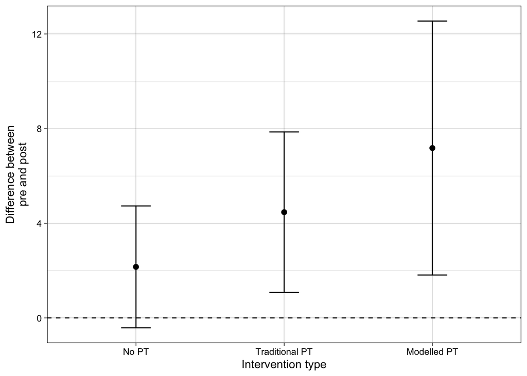

```r
# plot
plot_prepost_mass <- data_processed_after_exclusions %>%
  select(mass_diff_pre_post, condition) %>%
  drop_na() %>%
  group_by(condition) %>%
  summarize(mean = mean(mass_diff_pre_post),
            se = plotrix::std.error(mass_diff_pre_post)) %>%
  plot_condition_main_effect() +
  ylab("Difference between\npre and post")

# print
plot_prepost_mass
```

```r
# save pdf
ggsave(plot = plot_prepost_mass,
       device = "pdf",
       filename = "plot_prepost_mass.pdf",
       path = "plots/",
       units = "in",
       width = 6.5,
       height = 4)
```

### MHS-G

```r
# fit anova
fit_mhs_g_post <-
  ezANOVA(data     = data_processed_after_exclusions,
          dv       = mhs_g_diff_pre_post,
          between  = condition,
          wid      = id,
          type     = 3,
          detailed = TRUE)

# automatically format results
anova_out(fit_mhs_g_post, print = FALSE)$`--- FORMATTED RESULTS ------------------------------------` %>%
  # print
  kable()  %>%
  kable_styling(bootstrap_options = c("striped", "hover", "condensed"), full_width = FALSE)
```

| Effect | Text |
| --- | --- |
| (Intercept) | F(1, 136) = 58.14, p < .001, np2 = .30 |
| condition | F(2, 136) = 0.82, p = .443, np2 = .01 |

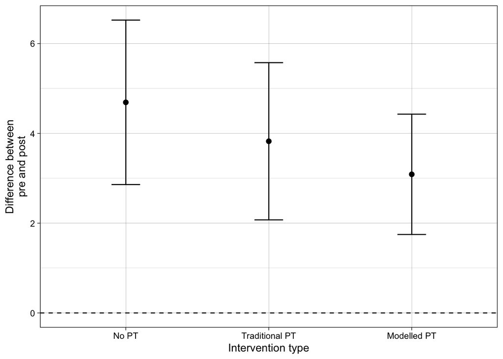

```r
# plot
plot_prepost_mhs_g <- data_processed_after_exclusions %>%
  select(mhs_g_diff_pre_post, condition) %>%
  drop_na() %>%
  group_by(condition) %>%
  summarize(mean = mean(mhs_g_diff_pre_post),
            se = plotrix::std.error(mhs_g_diff_pre_post)) %>%
  plot_condition_main_effect() +
  ylab("Difference between\npre and post")

# print
plot_prepost_mhs_g
```

```r
# save pdf
ggsave(plot = plot_prepost_mhs_g,
       device = "pdf",
       filename = "plot_prepost_mhs_g.pdf",
       path = "plots/",
       units = "in",
       width = 6.5,
       height = 4)
```

### MHS-L

```r
# fit anova
fit_mhs_l_post <-
  ezANOVA(data     = data_processed_after_exclusions,
          dv       = mhs_l_diff_pre_post,
          between  = condition,
          wid      = id,
          type     = 3,
          detailed = TRUE)

# automatically format results
anova_out(fit_mhs_l_post, print = FALSE)$`--- FORMATTED RESULTS ------------------------------------` %>%
  # print
  kable()  %>%
  kable_styling(bootstrap_options = c("striped", "hover", "condensed"), full_width = FALSE)
```

| Effect | Text |
| --- | --- |
| (Intercept) | F(1, 136) = 28.66, p < .001, np2 = .17 |
| condition | F(2, 136) = 0.22, p = .803, np2 < .01 |

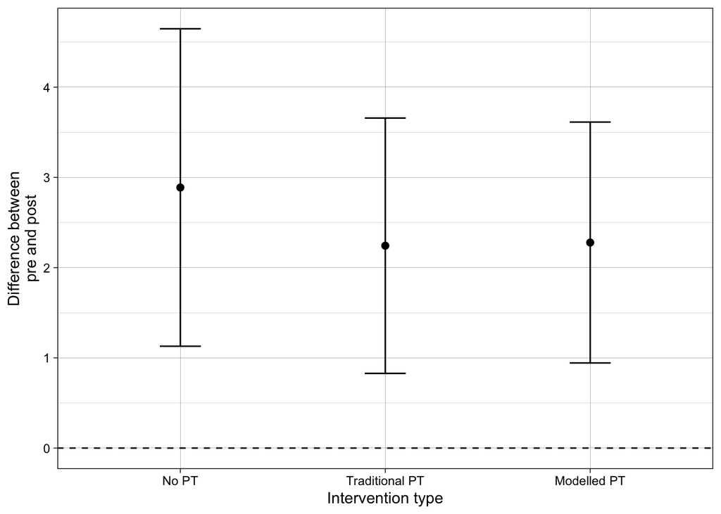

```r
# plot
plot_prepost_mhs_l <- data_processed_after_exclusions %>%
  select(mhs_l_diff_pre_post, condition) %>%
  drop_na() %>%
  group_by(condition) %>%
  summarize(mean = mean(mhs_l_diff_pre_post),
            se = plotrix::std.error(mhs_l_diff_pre_post)) %>%
  plot_condition_main_effect() +
  ylab("Difference between\npre and post")

# print
plot_prepost_mhs_l
```

```r
# save pdf
ggsave(plot = plot_prepost_mhs_l,
       device = "pdf",
       filename = "plot_prepost_mhs_l.pdf",
       path = "plots/",
       units = "in",
       width = 6.5,
       height = 4)
```

## Pre-followup

### MASS

```r
# fit anova
fit_mass_followup <- data_processed_after_exclusions %>%
  select(id, mass_diff_pre_followup, condition) %>%
  drop_na() %>%
  ezANOVA(data     = .,
          dv       = mass_diff_pre_followup,
          between  = condition,
          wid      = id,
          type     = 3,
          detailed = TRUE)

# automatically format results
anova_out(fit_mass_followup, print = FALSE)$`--- FORMATTED RESULTS ------------------------------------` %>%
  # print
  kable()  %>%
  kable_styling(bootstrap_options = c("striped", "hover", "condensed"), full_width = FALSE)
```

| Effect | Text |
| --- | --- |
| (Intercept) | F(1, 107) = 0.01, p = .934, np2 < .01 |
| condition | F(2, 107) = 1.25, p = .290, np2 = .02 |

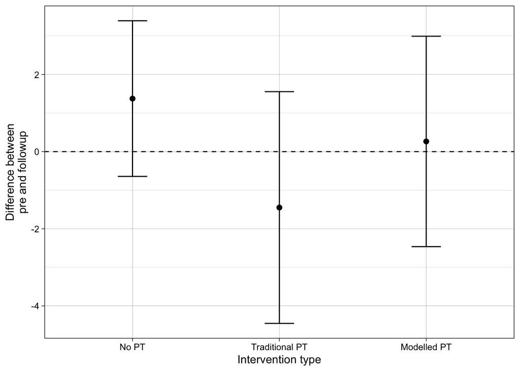

```r
# plot
plot_prefollowup_mass <- data_processed_after_exclusions %>%
  select(mass_diff_pre_followup, condition) %>%
  drop_na() %>%
  group_by(condition) %>%
  summarize(mean = mean(mass_diff_pre_followup),
            se = plotrix::std.error(mass_diff_pre_followup)) %>%
  plot_condition_main_effect() +
  ylab("Difference between\npre and followup")

# print
plot_prefollowup_mass
```

```r
# save pdf
ggsave(plot = plot_prefollowup_mass,
       device = "pdf",
       filename = "plot_prefollowup_mass.pdf",
       path = "plots/",
       units = "in",
       width = 6.5,
       height = 4)
```

### MHS-G

```r
# fit anova
fit_mhs_g_followup <- data_processed_after_exclusions %>%
  select(id, mhs_g_diff_pre_followup, condition) %>%
  drop_na() %>%
  ezANOVA(data     = .,
          dv       = mhs_g_diff_pre_followup,
          between  = condition,
          wid      = id,
          type     = 3,
          detailed = TRUE)

# automatically format results
anova_out(fit_mhs_g_followup, print = FALSE)$`--- FORMATTED RESULTS ------------------------------------` %>%
  # print
  kable()  %>%
  kable_styling(bootstrap_options = c("striped", "hover", "condensed"), full_width = FALSE)
```

| Effect | Text |
| --- | --- |
| (Intercept) | F(1, 107) = 24.24, p < .001, np2 = .18 |
| condition | F(2, 107) = 1.02, p = .365, np2 = .02 |

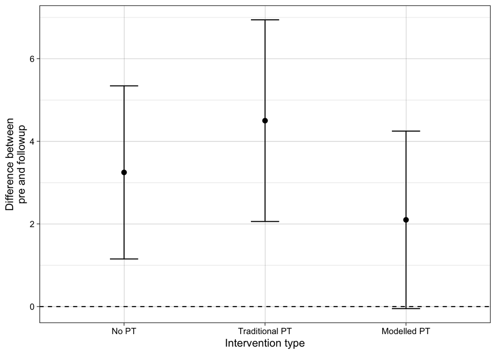

```r
# plot
plot_prefollowup_mhs_g <- data_processed_after_exclusions %>%
  select(mhs_g_diff_pre_followup, condition) %>%
  drop_na() %>%
  group_by(condition) %>%
  summarize(mean = mean(mhs_g_diff_pre_followup),
            se = plotrix::std.error(mhs_g_diff_pre_followup)) %>%
  plot_condition_main_effect() +
  ylab("Difference between\npre and followup")

# print
plot_prefollowup_mhs_g
```

```r
# save pdf
ggsave(plot = plot_prefollowup_mhs_g,
       device = "pdf",
       filename = "plot_prefollowup_mhs_g.pdf",
       path = "plots/",
       units = "in",
       width = 6.5,
       height = 4)
```

### MHS-L

```r
# fit anova
fit_mhs_l_followup <- data_processed_after_exclusions %>%
  select(id, mhs_l_diff_pre_followup, condition) %>%
  drop_na() %>%
  ezANOVA(data     = .,
          dv       = mhs_l_diff_pre_followup,
          between  = condition,
          wid      = id,
          type     = 3,
          detailed = TRUE)

# automatically format results
anova_out(fit_mhs_l_followup, print = FALSE)$`--- FORMATTED RESULTS ------------------------------------` %>%
  # print
  kable()  %>%
  kable_styling(bootstrap_options = c("striped", "hover", "condensed"), full_width = FALSE)
```

| Effect | Text |
| --- | --- |
| (Intercept) | F(1, 107) = 16.50, p < .001, np2 = .13 |
| condition | F(2, 107) = 0.90, p = .411, np2 = .02 |

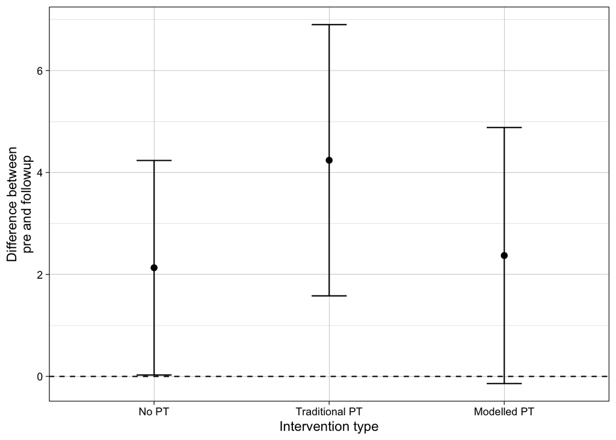

```r
# plot
plot_prefollowup_mhs_l <- data_processed_after_exclusions %>%
  select(mhs_l_diff_pre_followup, condition) %>%
  drop_na() %>%
  group_by(condition) %>%
  summarize(mean = mean(mhs_l_diff_pre_followup),
            se = plotrix::std.error(mhs_l_diff_pre_followup)) %>%
  plot_condition_main_effect() +
  ylab("Difference between\npre and followup")

# print
plot_prefollowup_mhs_l
```

```r
# save pdf
ggsave(plot = plot_prefollowup_mhs_l,
       device = "pdf",
       filename = "plot_prefollowup_mhs_l.pdf",
       path = "plots/",
       units = "in",
       width = 6.5,
       height = 4)
```

## Post-followup

### MASS

```r
# fit anova
fit_mass_post_followup <- data_processed_after_exclusions %>%
  select(id, mass_diff_post_followup, condition) %>%
  drop_na() %>%
  ezANOVA(data     = .,
          dv       = mass_diff_post_followup,
          between  = condition,
          wid      = id,
          type     = 3,
          detailed = TRUE)

# automatically format results
anova_out(fit_mass_post_followup, print = FALSE)$`--- FORMATTED RESULTS ------------------------------------` %>%
  # print
  kable()  %>%
  kable_styling(bootstrap_options = c("striped", "hover", "condensed"), full_width = FALSE)
```

| Effect | Text |
| --- | --- |
| (Intercept) | F(1, 107) = 17.61, p < .001, np2 = .14 |
| condition | F(2, 107) = 3.51, p = .033, np2 = .06 |

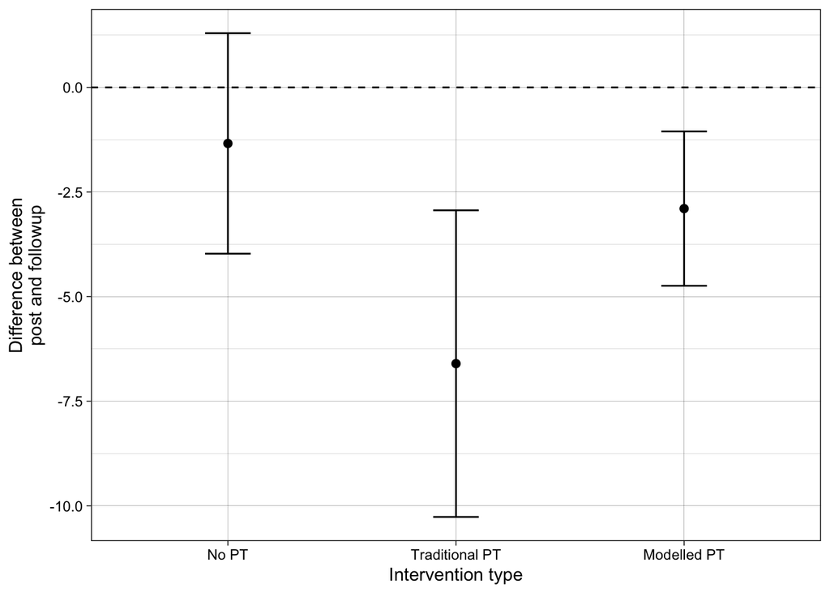

```r
# plot
plot_post_followup_mass <- data_processed_after_exclusions %>%
  select(mass_diff_post_followup, condition) %>%
  drop_na() %>%
  group_by(condition) %>%
  summarize(mean = mean(mass_diff_post_followup),
            se = plotrix::std.error(mass_diff_post_followup)) %>%
  plot_condition_main_effect() +
  ylab("Difference between\npost and followup")

# print
plot_post_followup_mass
```

```r
# save pdf
ggsave(plot = plot_post_followup_mass,
       device = "pdf",
       filename = "plot_post_followup_mass.pdf",
       path = "plots/",
       units = "in",
       width = 6.5,
       height = 4)
```

### MHS-G

```r
# fit anova
fit_mhs_g_post_followup <- data_processed_after_exclusions %>%
  select(id, mhs_g_diff_post_followup, condition) %>%
  drop_na() %>%
  ezANOVA(data     = .,
          dv       = mhs_g_diff_post_followup,
          between  = condition,
          wid      = id,
          type     = 3,
          detailed = TRUE)

# automatically format results
anova_out(fit_mhs_g_post_followup, print = FALSE)$`--- FORMATTED RESULTS ------------------------------------` %>%
  # print
  kable()  %>%
  kable_styling(bootstrap_options = c("striped", "hover", "condensed"), full_width = FALSE)
```

| Effect | Text |
| --- | --- |
| (Intercept) | F(1, 107) = 0.81, p = .371, np2 = .01 |
| condition | F(2, 107) = 1.23, p = .298, np2 = .02 |

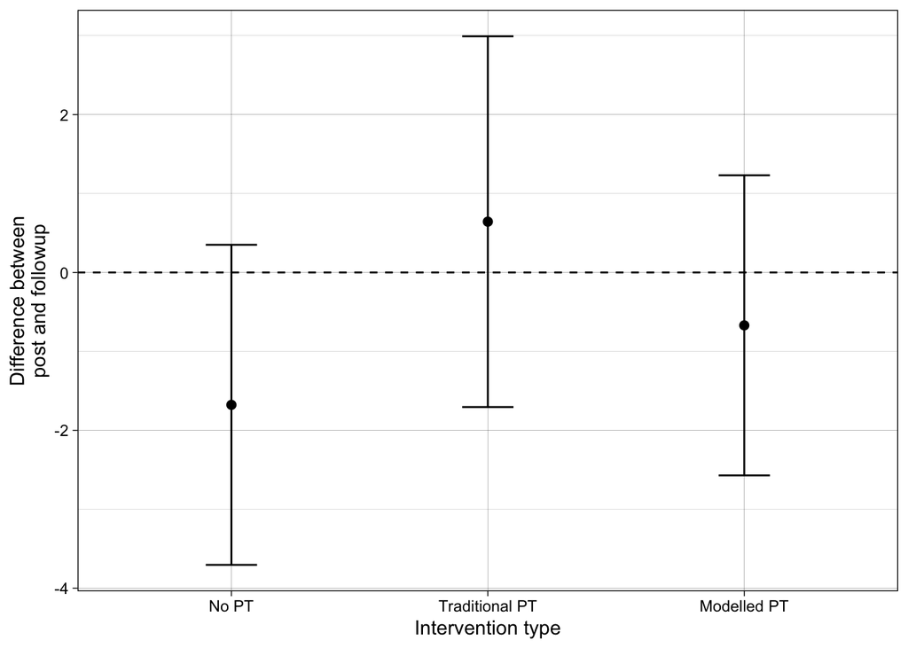

```r
# plot
plot_post_followup_mhs_g <- data_processed_after_exclusions %>%
  select(mhs_g_diff_post_followup, condition) %>%
  drop_na() %>%
  group_by(condition) %>%
  summarize(mean = mean(mhs_g_diff_post_followup),
            se = plotrix::std.error(mhs_g_diff_post_followup)) %>%
  plot_condition_main_effect() +
  ylab("Difference between\npost and followup")

# print
plot_post_followup_mhs_g
```

```r
# save pdf
ggsave(plot = plot_post_followup_mhs_g,
       device = "pdf",
       filename = "plot_post_followup_mhs_g.pdf",
       path = "plots/",
       units = "in",
       width = 6.5,
       height = 4)
```

### MHS-L

```r
# fit anova
fit_mhs_l_post_followup <- data_processed_after_exclusions %>%
  select(id, mhs_l_diff_post_followup, condition) %>%
  drop_na() %>%
  ezANOVA(data     = .,
          dv       = mhs_l_diff_post_followup,
          between  = condition,
          wid      = id,
          type     = 3,
          detailed = TRUE)

# automatically format results
anova_out(fit_mhs_l_post_followup, print = FALSE)$`--- FORMATTED RESULTS ------------------------------------` %>%
  # print
  kable()  %>%
  kable_styling(bootstrap_options = c("striped", "hover", "condensed"), full_width = FALSE)
```

| Effect | Text |
| --- | --- |
| (Intercept) | F(1, 107) = 0.84, p = .362, np2 = .01 |
| condition | F(2, 107) = 1.80, p = .170, np2 = .03 |

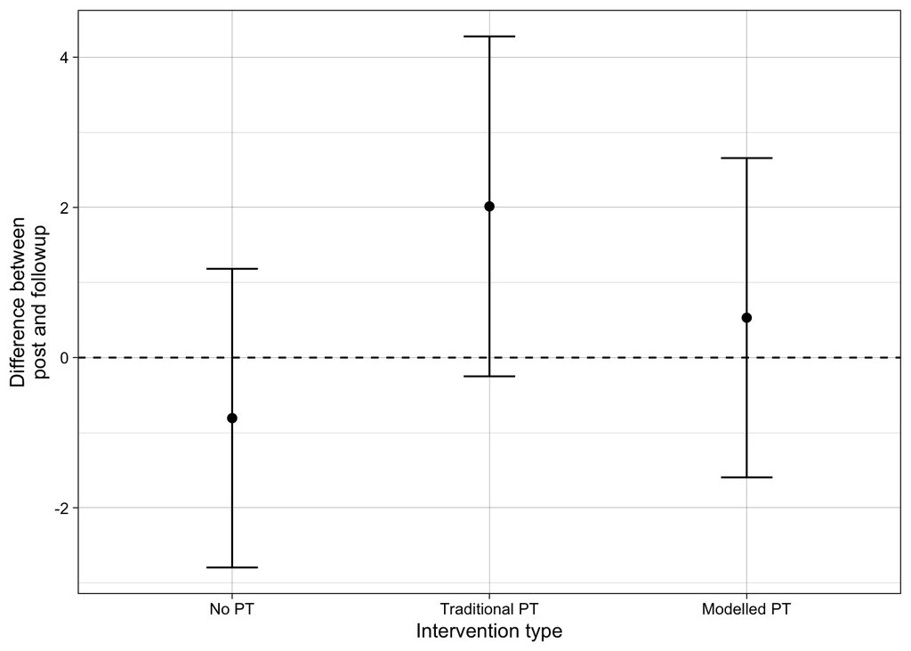

```r
# plot
plot_post_followup_mhs_l <- data_processed_after_exclusions %>%
  select(mhs_l_diff_post_followup, condition) %>%
  drop_na() %>%
  group_by(condition) %>%
  summarize(mean = mean(mhs_l_diff_post_followup),
            se = plotrix::std.error(mhs_l_diff_post_followup)) %>%
  plot_condition_main_effect() +
  ylab("Difference between\npost and followup")

# print
plot_post_followup_mhs_l
```

```r
# save pdf
ggsave(plot = plot_post_followup_mhs_l,
       device = "pdf",
       filename = "plot_post_followup_mhs_l.pdf",
       path = "plots/",
       units = "in",
       width = 6.5,
       height = 4)
```

## Test assumptions

### Normality

Distribution plots

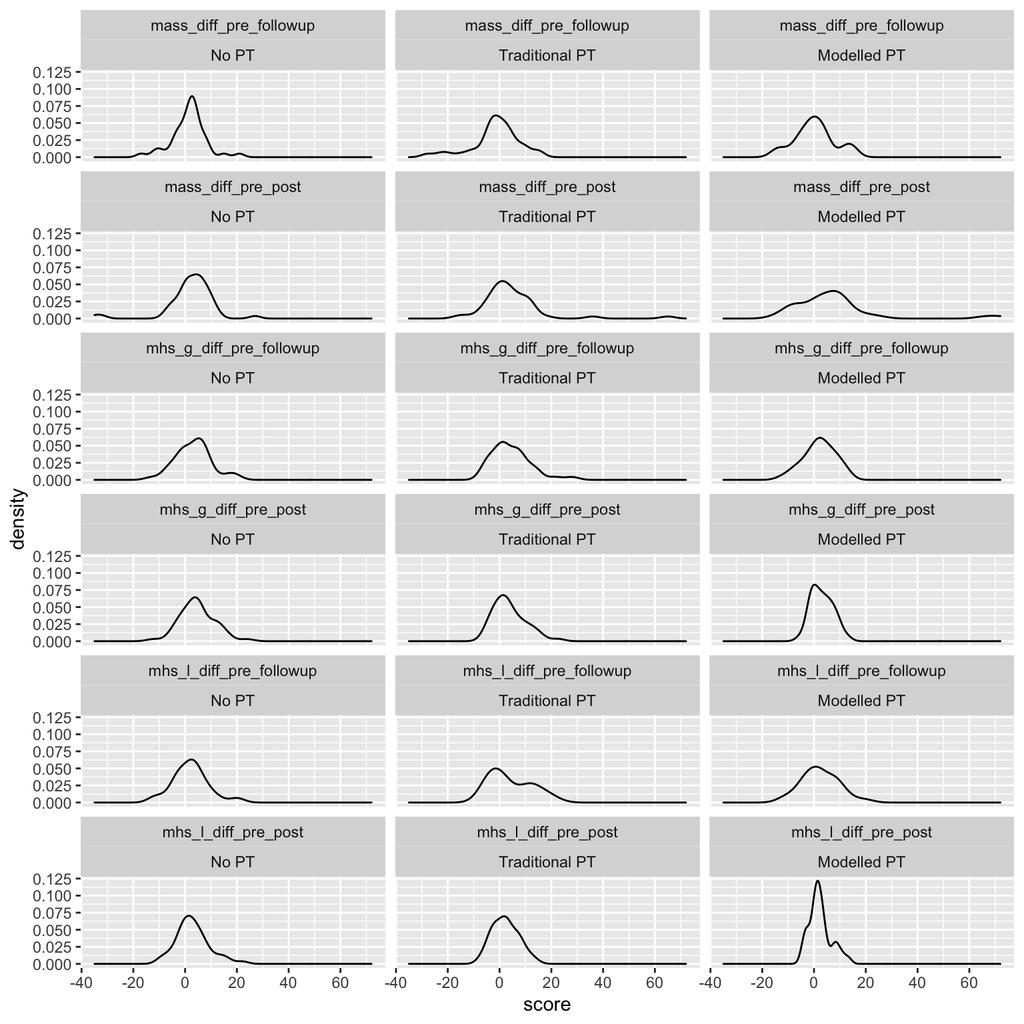

```r
data_reshaped <- data_processed_after_exclusions %>%
  select(condition,
         mass_diff_pre_post,
         mhs_g_diff_pre_post,
         mhs_l_diff_pre_post,
         mass_diff_pre_followup,
         mhs_g_diff_pre_followup,
         mhs_l_diff_pre_followup) %>%
  gather(scale, score, c(-condition))

ggplot(data_reshaped, aes(score)) +
  geom_density(alpha = 0.3) +
  facet_wrap(~ scale + condition, ncol = 3)
```

Q-Q plots

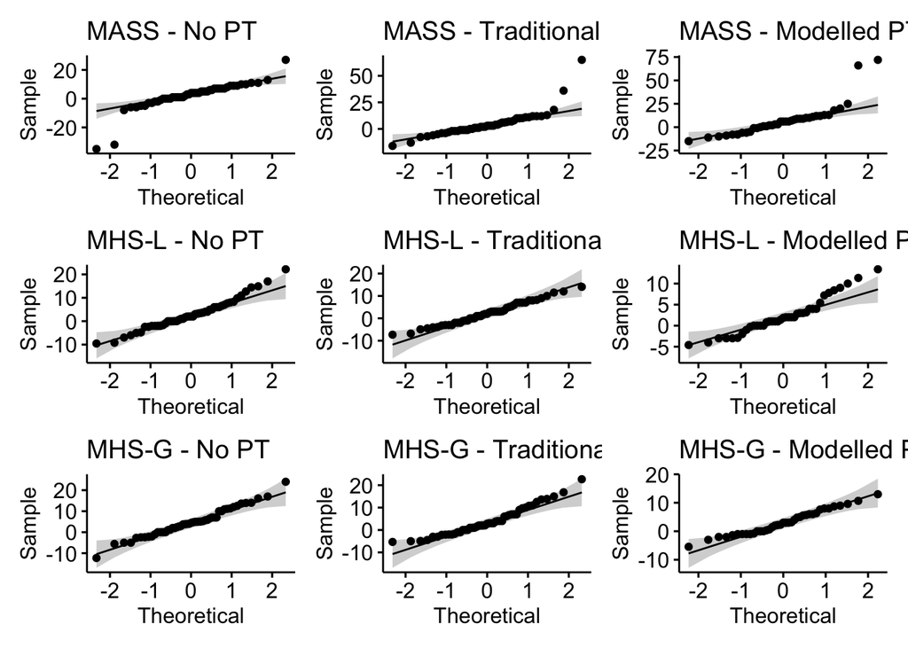

```r
library(ggpubr)
p1 <- ggqqplot(data_processed_after_exclusions$mass_diff_pre_post[data_processed_after_exclusions$condition == "No PT"],
               title = "MASS - No PT")
p2 <- ggqqplot(data_processed_after_exclusions$mhs_g_diff_pre_post[data_processed_after_exclusions$condition == "No PT"],
               title = "MHS-G - No PT")
p3 <- ggqqplot(data_processed_after_exclusions$mhs_l_diff_pre_post[data_processed_after_exclusions$condition == "No PT"],
               title = "MHS-L - No PT")
p4 <- ggqqplot(data_processed_after_exclusions$mass_diff_pre_followup[data_processed_after_exclusions$condition == "No PT"],
               title = "MASS - No PT")
p5 <- ggqqplot(data_processed_after_exclusions$mhs_g_diff_pre_followup[data_processed_after_exclusions$condition == "No PT"],
               title = "MHS-G - No PT")
p6 <- ggqqplot(data_processed_after_exclusions$mhs_l_diff_pre_followup[data_processed_after_exclusions$condition == "No PT"],
               title = "MHS-L - No PT")

p7 <- ggqqplot(data_processed_after_exclusions$mass_diff_pre_post[data_processed_after_exclusions$condition == "Traditional PT"],
               title = "MASS - Traditional PT")
p8 <- ggqqplot(data_processed_after_exclusions$mhs_g_diff_pre_post[data_processed_after_exclusions$condition == "Traditional PT"],
               title = "MHS-G - Traditional PT")
p9 <- ggqqplot(data_processed_after_exclusions$mhs_l_diff_pre_post[data_processed_after_exclusions$condition == "Traditional PT"],
               title = "MHS-L - Traditional PT")
p10 <- ggqqplot(data_processed_after_exclusions$mass_diff_pre_followup[data_processed_after_exclusions$condition == "Traditional PT"],
               title = "MASS - Traditional PT")
p11 <- ggqqplot(data_processed_after_exclusions$mhs_g_diff_pre_followup[data_processed_after_exclusions$condition == "Traditional PT"],
               title = "MHS-G - Traditional PT")
p12 <- ggqqplot(data_processed_after_exclusions$mhs_l_diff_pre_followup[data_processed_after_exclusions$condition == "Traditional PT"],
               title = "MHS-L - Traditional PT")

p13 <- ggqqplot(data_processed_after_exclusions$mass_diff_pre_post[data_processed_after_exclusions$condition == "Modelled PT"],
               title = "MASS - Modelled PT")
p14 <- ggqqplot(data_processed_after_exclusions$mhs_g_diff_pre_post[data_processed_after_exclusions$condition == "Modelled PT"],
               title = "MHS-G - Modelled PT")
p15 <- ggqqplot(data_processed_after_exclusions$mhs_l_diff_pre_post[data_processed_after_exclusions$condition == "Modelled PT"],
               title = "MHS-L - Modelled PT")
p16 <- ggqqplot(data_processed_after_exclusions$mass_diff_pre_followup[data_processed_after_exclusions$condition == "Modelled PT"],
               title = "MASS - Modelled PT")
p17 <- ggqqplot(data_processed_after_exclusions$mhs_g_diff_pre_followup[data_processed_after_exclusions$condition == "Modelled PT"],
               title = "MHS-G - Modelled PT")
p18 <- ggqqplot(data_processed_after_exclusions$mhs_l_diff_pre_followup[data_processed_after_exclusions$condition == "Modelled PT"],
               title = "MHS-L - Modelled PT")

library(patchwork)

plot_QQ_prepost <-
  p1 +
  p7 +
  p13 +
  p3 +
  p9 +
  p15 +
  p2 +
  p8 +
  p14 +
  plot_layout(ncol = 3)

plot_QQ_prefollowup <-
  p4 +
  p10 +
  p16 +
  p5 +
  p11 +
  p17 +
  p6 +
  p12 +
  p18 +
  plot_layout(ncol = 3)

plot_QQ_prepost
```

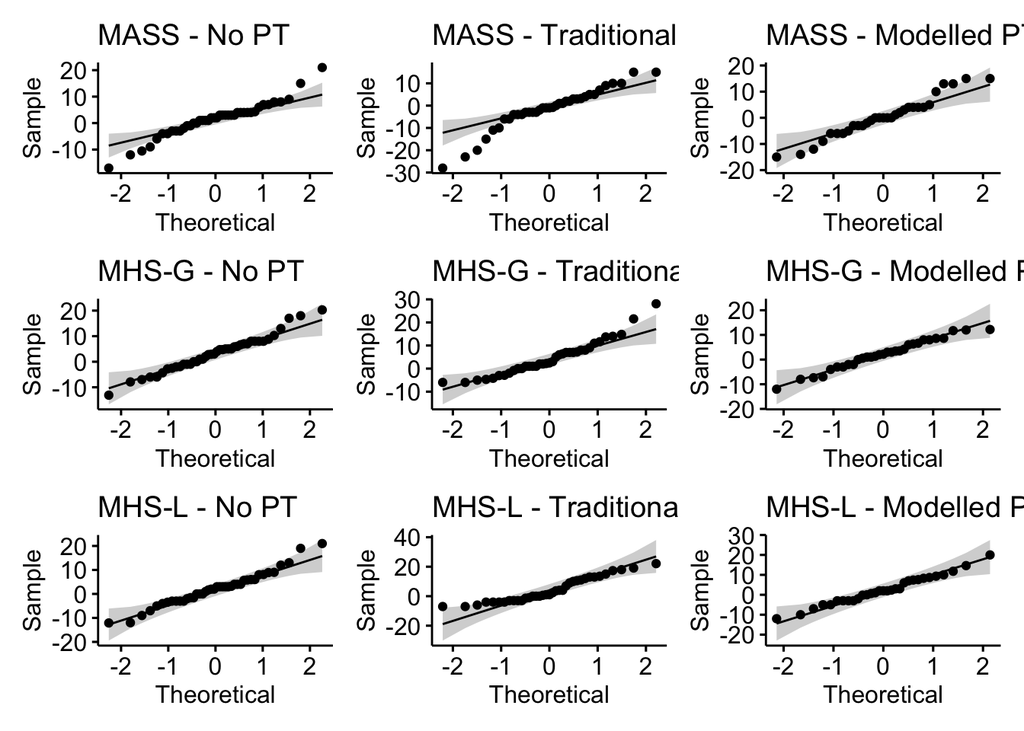

```r
plot_QQ_prefollowup
```

```r
ggsave(plot = plot_QQ_prepost,
       device = "pdf",
       filename = "plot_QQ_prepost.pdf",
       path = "plots/",
       units = "in",
       width = 12,
       height = 12)

ggsave(plot = plot_QQ_prefollowup,
       device = "pdf",
       filename = "plot_QQ_prefollowup.pdf",
       path = "plots/",
       units = "in",
       width = 12,
       height = 12)
```

Shaprio-Wilks tests

```r
tidy_shaprio_wilks_test <- function(data) {
  fit <- shapiro.test(data$score)

  results <- tibble(W = round(fit$statistic, 2),
                    p = fit$p.value)

  return(results)
}

full_join(
  data_reshaped %>%
    group_by(scale, condition) %>%
    do(tidy_shaprio_wilks_test(.)),
  data_reshaped %>%
    count(scale, condition),
  by = c("scale", "condition")
) %>%
  mutate(p = round(p, 3)) %>%
  select(scale, condition, n, W, p) %>%
  kable()  %>%
  kable_styling(bootstrap_options = c("striped", "hover", "condensed"), full_width = FALSE)
```

| scale | condition | n | W | p |
| --- | --- | --- | --- | --- |
| mass_diff_pre_followup | No PT | 51 | 0.95 | 0.044 |
| mass_diff_pre_followup | Traditional PT | 49 | 0.93 | 0.027 |
| mass_diff_pre_followup | Modelled PT | 39 | 0.96 | 0.332 |
| mass_diff_pre_post | No PT | 51 | 0.80 | 0.000 |
| mass_diff_pre_post | Traditional PT | 49 | 0.75 | 0.000 |
| mass_diff_pre_post | Modelled PT | 39 | 0.75 | 0.000 |
| mhs_g_diff_pre_followup | No PT | 51 | 0.98 | 0.682 |
| mhs_g_diff_pre_followup | Traditional PT | 49 | 0.93 | 0.024 |
| mhs_g_diff_pre_followup | Modelled PT | 39 | 0.98 | 0.690 |
| mhs_g_diff_pre_post | No PT | 51 | 0.98 | 0.619 |
| mhs_g_diff_pre_post | Traditional PT | 49 | 0.95 | 0.024 |
| mhs_g_diff_pre_post | Modelled PT | 39 | 0.97 | 0.518 |
| mhs_l_diff_pre_followup | No PT | 51 | 0.97 | 0.282 |
| mhs_l_diff_pre_followup | Traditional PT | 49 | 0.92 | 0.015 |
| mhs_l_diff_pre_followup | Modelled PT | 39 | 0.99 | 0.951 |
| mhs_l_diff_pre_post | No PT | 51 | 0.97 | 0.167 |
| mhs_l_diff_pre_post | Traditional PT | 49 | 0.98 | 0.663 |
| mhs_l_diff_pre_post | Modelled PT | 39 | 0.94 | 0.049 |

### Homoscedasticity

```r
bind_rows(
  fit_mass_post$`Levene's Test for Homogeneity of Variance` %>%
    select(`F`, p),
  fit_mhs_g_post$`Levene's Test for Homogeneity of Variance` %>%
    select(`F`, p),
  fit_mhs_l_post$`Levene's Test for Homogeneity of Variance` %>%
    select(`F`, p),
  fit_mass_followup$`Levene's Test for Homogeneity of Variance` %>%
    select(`F`, p),
  fit_mhs_g_followup$`Levene's Test for Homogeneity of Variance` %>%
    select(`F`, p),
  fit_mhs_l_followup$`Levene's Test for Homogeneity of Variance` %>%
    select(`F`, p)
) %>%
  mutate(scale_and_timepoint = c("mass pre-post",
                                 "mhs_g pre-post",
                                 "mhs_l pre-post",
                                 "mass pre-followup",
                                 "mhs_g pre-followup",
                                 "mhs_l pre-followup")) %>%
  select(scale_and_timepoint, `F`, p) %>%
  mutate_if(is.numeric, round, digits = 2) %>%
  # print
  kable()  %>%
  kable_styling(bootstrap_options = c("striped", "hover", "condensed"), full_width = FALSE)
```

| scale_and_timepoint | F | p |
| --- | --- | --- |
| mass pre-post | 2.07 | 0.13 |
| mhs_g pre-post | 1.96 | 0.14 |
| mhs_l pre-post | 2.41 | 0.09 |
| mass pre-followup | 1.22 | 0.30 |
| mhs_g pre-followup | 0.40 | 0.67 |
| mhs_l pre-followup | 1.28 | 0.28 |

## Non parametric tests

### Pre-post

#### MASS

```r
kruskal.test(mass_diff_pre_post ~ condition,
             data = data_processed_after_exclusions)
```

```
##
##  Kruskal-Wallis rank sum test
##
## data:  mass_diff_pre_post by condition
## Kruskal-Wallis chi-squared = 1.2417, df = 2, p-value = 0.5375
```

#### MHS-G

```r
kruskal.test(mhs_g_diff_pre_post ~ condition,
             data = data_processed_after_exclusions)
```

```
##
##  Kruskal-Wallis rank sum test
##
## data:  mhs_g_diff_pre_post by condition
## Kruskal-Wallis chi-squared = 1.4538, df = 2, p-value = 0.4834
```

#### MHS-L

```r
kruskal.test(mhs_l_diff_pre_post ~ condition,
             data = data_processed_after_exclusions)
```

```
##
##  Kruskal-Wallis rank sum test
##
## data:  mhs_l_diff_pre_post by condition
## Kruskal-Wallis chi-squared = 0.24656, df = 2, p-value = 0.884
```

### Pre-followup

#### MASS

```r
kruskal.test(mass_diff_pre_followup ~ condition,
             data = data_processed_after_exclusions)
```

```
##
##  Kruskal-Wallis rank sum test
##
## data:  mass_diff_pre_followup by condition
## Kruskal-Wallis chi-squared = 2.3089, df = 2, p-value = 0.3152
```

#### MHS-G

```r
kruskal.test(mhs_g_diff_pre_followup ~ condition,
             data = data_processed_after_exclusions)
```

```
##
##  Kruskal-Wallis rank sum test
##
## data:  mhs_g_diff_pre_followup by condition
## Kruskal-Wallis chi-squared = 0.89505, df = 2, p-value = 0.6392
```

#### MHS-L

```r
kruskal.test(mhs_l_diff_pre_followup ~ condition,
             data = data_processed_after_exclusions)
```

```
##
##  Kruskal-Wallis rank sum test
##
## data:  mhs_l_diff_pre_followup by condition
## Kruskal-Wallis chi-squared = 0.58958, df = 2, p-value = 0.7447
```

# ANOVAs and Chi Square

## Post

### Marriage Eq

```r
# fit anova
fit_marriage_eq_prepost <- data_processed_after_exclusions %>%
  select(id, agree_with_marriage_equality_prepost, condition) %>%
  drop_na() %>%
  ezANOVA(data     = .,
          dv       = agree_with_marriage_equality_prepost,
          between  = condition,
          wid      = id,
          type     = 3,
          detailed = TRUE)

# automatically format results
anova_out(fit_marriage_eq_prepost, print = FALSE)$`--- FORMATTED RESULTS ------------------------------------` %>%
  # print
  kable()  %>%
  kable_styling(bootstrap_options = c("striped", "hover", "condensed"), full_width = FALSE)
```

| Effect | Text |
| --- | --- |
| (Intercept) | F(1, 132) = 4196.78, p < .001, np2 = .97 |
| condition | F(2, 132) = 0.67, p = .511, np2 = .01 |

### Refuse Service

```r
# fit anova
fit_refuse_service_prepost <- data_processed_after_exclusions %>%
  select(id, business_right_to_refuse_sexuality_prepost, condition) %>%
  drop_na() %>%
  ezANOVA(data     = .,
          dv       = business_right_to_refuse_sexuality_prepost,
          between  = condition,
          wid      = id,
          type     = 3,
          detailed = TRUE)

# automatically format results
anova_out(fit_refuse_service_prepost, print = FALSE)$`--- FORMATTED RESULTS ------------------------------------` %>%
  # print
  kable()  %>%
  kable_styling(bootstrap_options = c("striped", "hover", "condensed"), full_width = FALSE)
```

| Effect | Text |
| --- | --- |
| (Intercept) | F(1, 40) = 110.44, p < .001, np2 = .73 |
| condition | F(2, 40) = 0.32, p = .726, np2 = .02 |

### Petition for Blood

```r
#Chi square condition
chisq.test(data_processed_after_exclusions$willingness_to_sign_petition_prepost, data_processed_after_exclusions$condition, correct=FALSE)
```

```
##
##  Pearson's Chi-squared test
##
## data:  data_processed_after_exclusions$willingness_to_sign_petition_prepost and data_processed_after_exclusions$condition
## X-squared = 0.60049, df = 2, p-value = 0.7406
```

## Follow-up

### Marriage Eq

```r
# fit anova
fit_marriage_eq_followup <- data_processed_after_exclusions %>%
  select(id, agree_with_marriage_equality_followup, condition) %>%
  drop_na() %>%
  ezANOVA(data     = .,
          dv       = agree_with_marriage_equality_followup,
          between  = condition,
          wid      = id,
          type     = 3,
          detailed = TRUE)

# automatically format results
anova_out(fit_marriage_eq_followup, print = FALSE)$`--- FORMATTED RESULTS ------------------------------------` %>%
  # print
  kable()  %>%
  kable_styling(bootstrap_options = c("striped", "hover", "condensed"), full_width = FALSE)
```

| Effect | Text |
| --- | --- |
| (Intercept) | F(1, 106) = 1546.95, p < .001, np2 = .94 |
| condition | F(2, 106) = 0.47, p = .623, np2 = .01 |

### Refuse Service

```r
# fit anova
fit_refuse_service_followup <- data_processed_after_exclusions %>%
  select(id, business_right_to_refuse_sexuality_followup, condition) %>%
  drop_na() %>%
  ezANOVA(data     = .,
          dv       = business_right_to_refuse_sexuality_followup,
          between  = condition,
          wid      = id,
          type     = 3,
          detailed = TRUE)

# automatically format results
anova_out(fit_refuse_service_followup, print = FALSE)$`--- FORMATTED RESULTS ------------------------------------` %>%
  # print
  kable() %>%
  kable_styling(bootstrap_options = c("striped", "hover", "condensed"), full_width = FALSE)
```

| Effect | Text |
| --- | --- |
| (Intercept) | F(1, 106) = 182.15, p < .001, np2 = .63 |
| condition | F(2, 106) = 0.48, p = .620, np2 = .01 |

### Petition for Blood

```r
#Chi square condition
chisq.test(data_processed_after_exclusions$willingness_to_sign_petition_followup, data_processed_after_exclusions$condition, correct=FALSE)
```

```
##
##  Pearson's Chi-squared test
##
## data:  data_processed_after_exclusions$willingness_to_sign_petition_followup and data_processed_after_exclusions$condition
## X-squared = 0.85419, df = 2, p-value = 0.6524
```

# IRI ANOVA

```r
# fit anova
fit_IRI <- data_processed_after_exclusions %>%
  select(id, iri_sum_score, condition) %>%
  drop_na() %>%
  ezANOVA(data     = .,
          dv       = iri_sum_score,
          between  = condition,
          wid      = id,
          type     = 1,
          detailed = TRUE)

# automatically format results
anova_out(fit_IRI, print = FALSE)$`--- FORMATTED RESULTS ------------------------------------` %>%
  # print
  kable()  %>%
  kable_styling(bootstrap_options = c("striped", "hover", "condensed"), full_width = FALSE)
```

| Effect | Text |
| --- | --- |
| condition | F(2, 136) = 0.00, p = .996, np2 < .01 |

# ToE ANOVA

```r
# fit anova
fit_ToE <- data_processed_after_exclusions %>%
  select(id, toe_sum_score, condition) %>%
  drop_na() %>%
  ezANOVA(data     = .,
          dv       = toe_sum_score,
          between  = condition,
          wid      = id,
          type     = 1,
          detailed = TRUE)

# automatically format results
anova_out(fit_ToE, print = FALSE)$`--- FORMATTED RESULTS ------------------------------------` %>%
  # print
  kable() %>%
  kable_styling(bootstrap_options = c("striped", "hover", "condensed"), full_width = FALSE)
```

| Effect | Text |
| --- | --- |
| condition | F(2, 136) = 2.41, p = .094, np2 = .03 |